# credit card customer churn EDA

# 3.浏览数据

首先，观察一下信用卡客户流失的整体情况

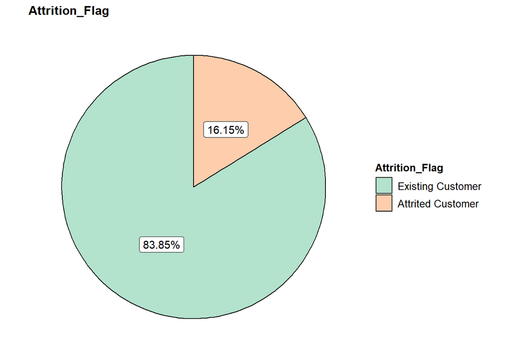

```r
ggpiestats(creditcard.train,"Attrition_Flag", results.subtitle = FALSE,
           slice.label = "percentage", perc.k = 2,palette = "Pastel2",
           title = "Attrition_Flag")
```

图中可见，信用卡客户绝大部分都留存下来，只有少数流失，说明数据十分不平衡，不利于拟合准确度高的模型，稍后需要进行过采样处理。接下来，再浏览客户特征的数据分布状况

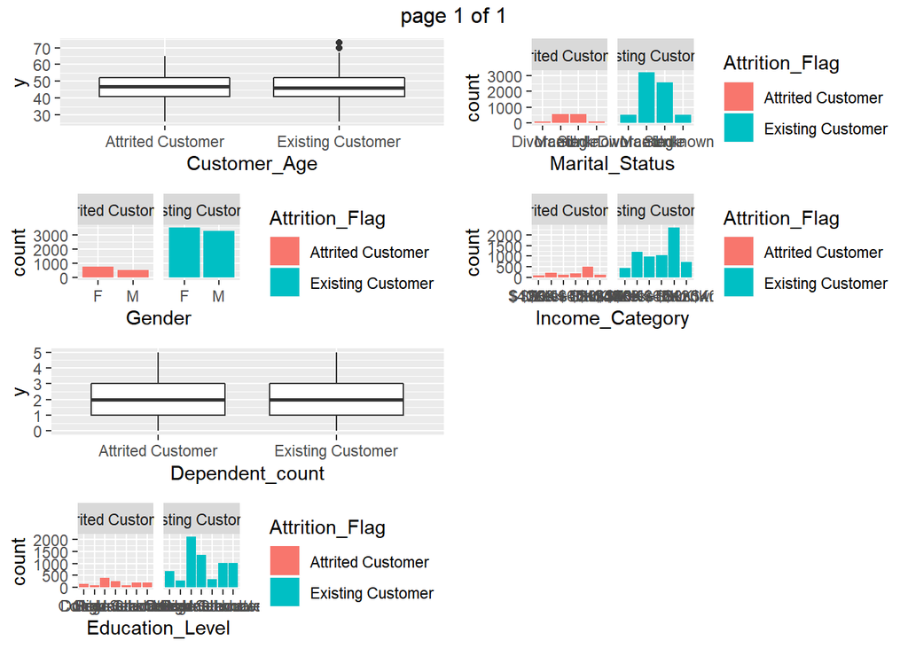

```r
customer.facet <- function(x){#数值型数据用箱型图展示，因子型数据用条形图展示
   y <- creditcard.train[,x]
   if(class(y)=="factor"){
   graph <- ggplot()+
     geom_bar(data = creditcard.train, aes(x = y, fill = Attrition_Flag))+
     labs(x = paste0(colnames(creditcard.train)[x]))+facet_grid(.~Attrition_Flag)
     }else{
      graph <- ggplot()+
        geom_boxplot(data = creditcard.train, aes(x =Attrition_Flag, y=y))+
        labs(x = paste0(colnames(creditcard.train)[x]))
     }
   return(graph)
}

customer.plot <- lapply(3:8,customer.facet)#3-8列特征属于客户特征
marrangeGrob(customer.plot,nrow = 4,ncol = 2)
```

从图中可以观察到，客户流失与否的客户特征各项分布都没有显示出明显的差异。后面，浏览商品特征的分布状况。

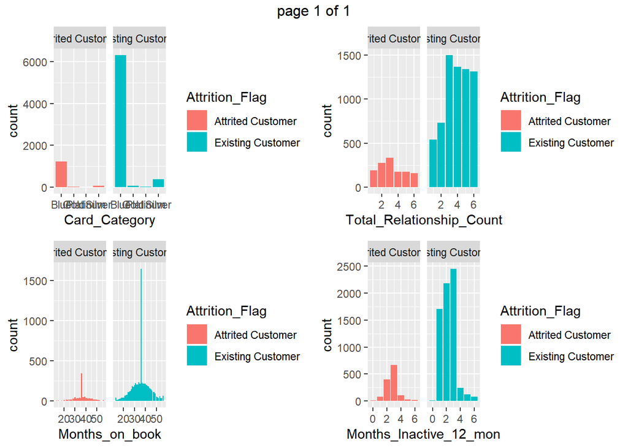

```r
product.facet <- function(x){
   y <- creditcard.train[,x]
   graph <- ggplot()+
     geom_bar(data = creditcard.train, aes(x = y, fill = Attrition_Flag))+
     labs(x = paste0(colnames(creditcard.train)[x]))+facet_grid(.~Attrition_Flag)
}

product.plot1 <- lapply(9:12,product.facet)#9-21列特征属于商品特征
marrangeGrob(product.plot1,nrow = 2,ncol = 2)
```

[figure not shown]

```r
product.plot2 <- lapply(13:16,product.facet)#9-21列特征属于商品特征
marrangeGrob(product.plot2,nrow = 2,ncol = 2)
```

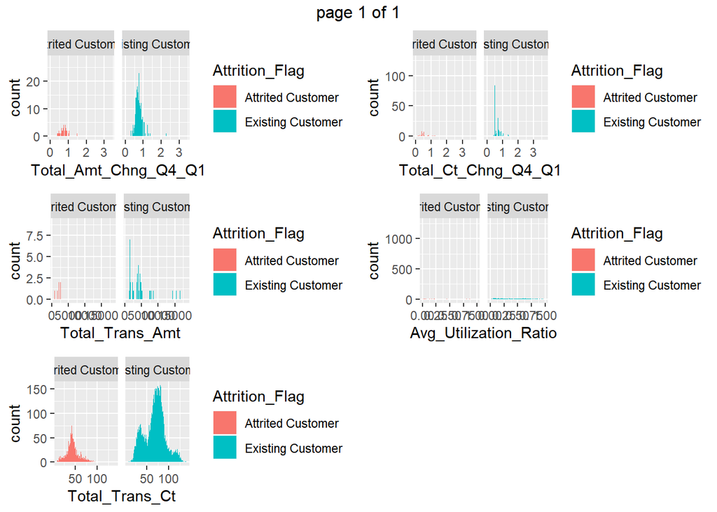

```r
product.plot3 <- lapply(17:21,product.facet)#9-21列特征属于商品特征
marrangeGrob(product.plot3,nrow = 3,ncol = 2)
```

从Total_Relationship_Count列（购买产品数）的图中可见，留存客户比流失客户更倾向于购买更多的产品；从Months_Inactive_12_mon列（失活的月数）的图中可见，留存客户多为活跃客户（失活月数不多于3个月）；从Contacts_Count_12_mon列（接触数）的图中可见，流失客户比留存客户有更多的接触次数；从Total_Revolving_Bal列（总循环平衡）的图中可见，流失客户的循环平衡比留存客户的低；从Total_Trans_Amt列（总消费金额）、Total_Trans_Ct列（总消费单数）、Total_Ct_Chng_Q4_Q1列的图中可见，流失客户的总消费金额和总消费单数比较低；最后，在Avg_Utilization_Ratio列（平均使用率）的图中可以得出，流失客户的平均使用率更低。其他的商品特征的流失与否分布情况则差异不大。

# 4.数据建模

## 4.1SMOTE算法采样

由于数据不平衡，即流失客户与留存客户的比例严重失调，在创建分类模型时可能会产生失准问题，因此需要对数据集运用SMOTE算法采样。SMOTE算法，即合成少数过采样技术，它是基于随机过采样算法的一种改进方案。SMOTE算法的基本思想就是对少数类别样本进行分析和KNN技术模拟，并将人工模拟的新样本添加到数据集中，具体：采样最邻近算法，计算出每个少数类样本的K个近邻，再从中随机挑选N个样本进行随机线性插值，构造新的少数类样本，最后将新样本与原数据合成，产生新的训练集。

```r
smote.data <- SMOTE(Attrition_Flag ~ .,creditcard.train)
table(smote.data$Attrition_Flag)
```

```
##
## Attrited Customer Existing Customer
##              3924              5232
```

## 4.2拟合模型

采用随机森林算法建模

```r
creditcard.randomforecast <- randomForest(Attrition_Flag~.,data = smote.data)
```

利用新的模型对测试集分类以检验模型性能

```r
creditcard.predict <- predict(creditcard.randomforecast, creditcard.test)
table(creditcard.predict)
```

```
## creditcard.predict
## Attrited Customer Existing Customer
##               349              1677
```

```r
table(test.classify)
```

```
## test.classify
## Attrited Customer Existing Customer
##               319              1707
```

从结果可以看出，预测的效果还是与实际值比较接近的，说明模型性能不错。最后再看一下各个特征的重要度

```r
feature.importance <- importance(creditcard.randomforecast,type = 2)
importance.df <- data.frame(feature=colnames(creditcard.train)[-2],
                            importance=feature.importance)
head(importance.df[order(-importance.df$MeanDecreaseGini),],5)
```

```
##                                     feature MeanDecreaseGini
## Total_Trans_Ct               Total_Trans_Ct         888.8081
## Total_Trans_Amt             Total_Trans_Amt         724.8939
## Total_Revolving_Bal     Total_Revolving_Bal         537.6859
## Total_Ct_Chng_Q4_Q1     Total_Ct_Chng_Q4_Q1         455.1081
## Avg_Utilization_Ratio Avg_Utilization_Ratio         249.6028
```